# Reproducible Research Project 1

Christopher Maier

January 22, 2017

## **Introduction**

It is now possible to collect a large amount of data about personal movement using activity monitoring devices. To motivate this ability, a particular personal activity monitoring device, which is able to collect data at 5 mintute intervals throughout the day, has monitored the daily personal movement of an anonymous individual. The data collected from this individual was done so over the the months of October and November 2012 and it includes the number of steps taken in 5 minute intervals during each day.

For this analysis, we seek to answer the following questions:

- What is the mean total number of steps taken per day?
- What are the mean and median number of steps taken each day?
- What is the average daily activity pattern?
- Which 5-minute interval, on average across all the days in the dataset, contains the maximum number of steps?
- The data have missing values associated to particular days. After imputing an imputation strategy, do these imputed values differ from the estimates from the earlier determined values?
- What is the impact of imputing missing data on the estimates of the total daily number of steps?
- Are there differences in activity patterns between weekdays and weekends?

## **Methods**

The mean total number of steps taken per day will be answered by calculating the total number of steps taken per day and then drawing a histogram of the total number of steps taken each day. Additionally, the mean and median number of steps taken each day will be reported.

To show what the average daily activity pattern is a time series plot of the 5-minute interval and the average number of steps taken, averaged across all days will be drawn. Using this data for the averages of the 5-minute intervals across all days in the data set, the maximum number of steps will be calculated.

## **Results**

### Loading and preprocessing the data

In order to obtain the data for this individual, the data was downloaded from Git Hub, as shown below. Note that for the analysis, no additional data cleaning/processing was performed.

```r
# Read in data from GitHub
# create "fileUrl" from which the data will come
fileUrl <- "https://raw.githubusercontent.com/Mooney721/RepData_PeerAssessment1/master/activity.csv"

# download data based on file URL and save in a destination file "./activity"
download.file(fileUrl, destfile = "./activity")

# read in activity data through .csv extension
activity <- read.csv("activity")
```

### What is mean total number of steps taken per day?

One question which is sought is to answer is “What is the mean total number of steps taken per day?”

In order to do this, the total number of steps taken per day was calculated and then a corresponding histogram was drawn.

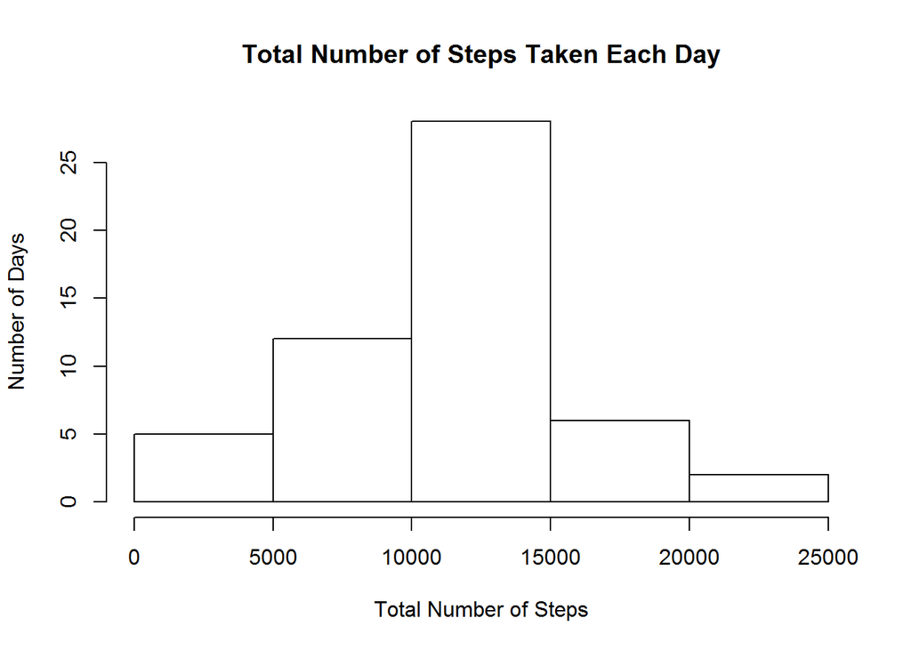

```r
# Calculate the total number of steps taken per day
totalStepsDay <- aggregate(steps ~ date, data = activity, FUN = sum)

# Make a histogram of the total number of steps taken in each day
hist(totalStepsDay$steps, main = "Total Number of Steps Taken Each Day",
     xlab = "Total Number of Steps",
     ylab = "Number of Days")
```

It is shown that, per day, between 10,000 and 15,000 steps have occurred with the highest frequency. To be sure, the mean and median of the total number of steps taken per day were calculated.

```r
# Calculate and report the mean and median of the total number of steps taken per day
meanTotalStepsDay <- mean(totalStepsDay$steps, na.rm = TRUE)
print(meanTotalStepsDay)
```

```
## [1] 10766.19
```

```r
medianTotalStepsDay <- median(totalStepsDay$steps, na.rm = TRUE)
print(medianTotalStepsDay)
```

```
## [1] 10765
```

### What is the average daily activity pattern?

The next question which is sought is “What is the average daily activity pattern?”. As previously mentioned, a time series plot is generated to show this, as well as to answer which 5-minute interval contains the maximum number of steps.

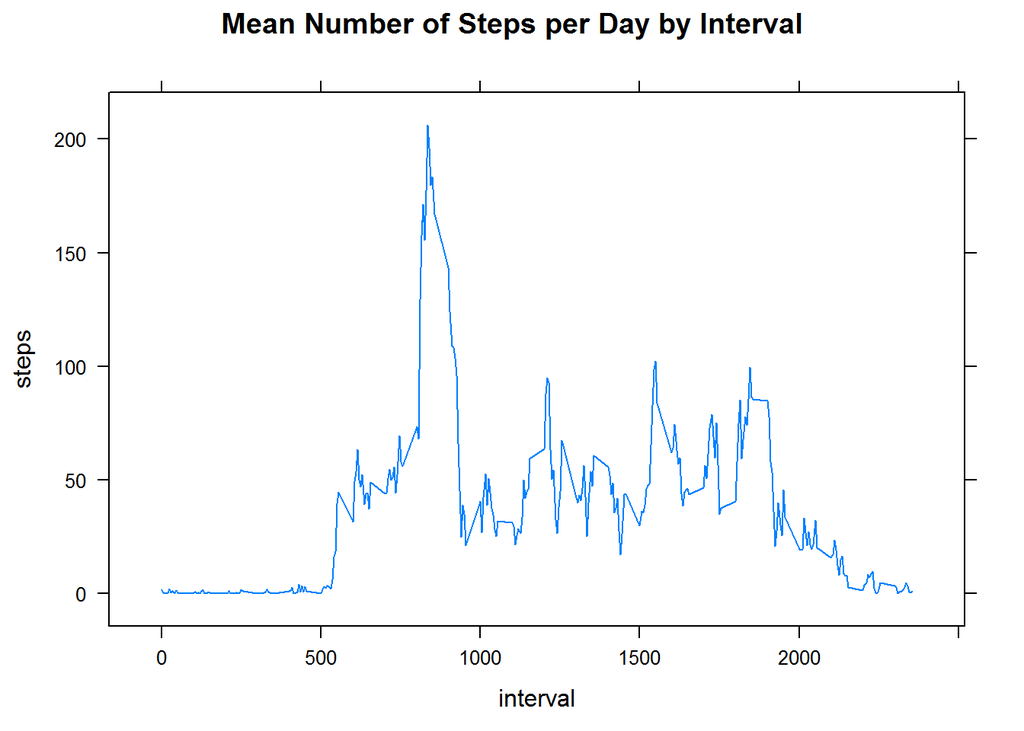

```r
# Making a time series plot of the 5-minute interval and the average number of steps taken, averaged across all days
# First, declare library(lattice) to create plot
library(lattice)
# Next, aggregate the mean number of steps by interval
meanStepsInterval <- aggregate(steps ~ interval, data = activity, na.rm = TRUE, FUN = mean)

# Drawing the time series plot
xyplot(steps ~ interval,
       data = meanStepsInterval,
       type = "l",
       main = "Mean Number of Steps per Day by Interval")
```

```r
# Calculating the 5-minute interval containing, on average, the maximum number of steps
fiveMinInt <- meanStepsInterval$interval[meanStepsInterval$steps == max(meanStepsInterval$steps)]
print(fiveMinInt)
```

```
## [1] 835
```

Based on the output, the interval displayed is 835. Thus, the 5-minute interval containing, on average, the maximum number of steps, is (830, 835).

### Imputing missing values

Next, the total number of missing values of the data set were be reported. This was done using the MICE (Multivariate Imputation by Chained Equations) in R. First, however, the total number of missing values in the data set (i.e., the total number of rows with NAs) were first reported.

```r
# Imputing missing values

# Calculate and report the total number of missing values in the dataset (i.e. the total number of rows with NAs)
missingSteps <- length(which(is.na(activity$steps == TRUE)))
print(missingSteps)
```

```
## [1] 2304
```

Thus, 2304 values were missing in the data set. These values were then imputed using MICE and a new data set was created based on the original data set, but with the imputed values.

```r
# Using MICE to impute missing values

# First, declare library(mice) for imputing missing values
library(mice)
# Second, use the MICE package to impute the missing values and create a new data set based on the original data set, but with imputed (no NA) values
set.seed(1)
activityMICE <- mice(activity)
activityNoNA <- complete(activityMICE)
```

Now that a new data set, based on the original data set, but containing imputed values has been created, a histogram of the total number of steps taken each day was drawn. Additionally, the calculations for the mean and median total number of steps taken per day were performed, similar to that which was done with the original data.

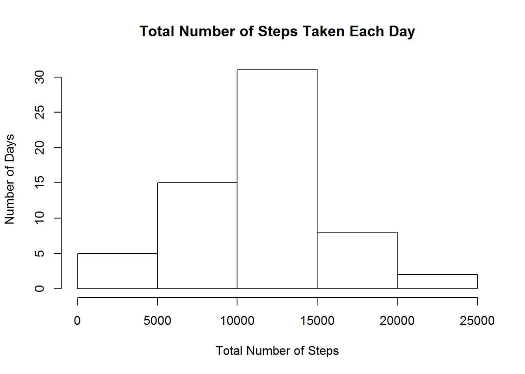

```r
# Next, calculate the total number of steps taken per day on implemented data
totalStepsDayNoNA <- aggregate(steps ~ date, data = activityNoNA, FUN = sum)

# Make a histogram of the total number of steps taken in each day with implemented data
hist(totalStepsDayNoNA$steps, main = "Total Number of Steps Taken Each Day",
     xlab = "Total Number of Steps",
     ylab = "Number of Days")
```

```r
# Calculate and report the mean and median of the total number of steps taken per day on implemented data
meanTotalStepsDayNoNA <- mean(totalStepsDayNoNA$steps)
print(meanTotalStepsDayNoNA)
```

```
## [1] 10885.57
```

```r
medianTotalStepsDayNoNA <- median(totalStepsDayNoNA$steps)
print(medianTotalStepsDayNoNA)
```

```
## [1] 10765
```

```r
# Calculating differences in mean and median of imputed data vs. non-imputed data
meanDiff <- meanTotalStepsDay - meanTotalStepsDayNoNA

medianDiff <- medianTotalStepsDay - medianTotalStepsDayNoNA
```

### Are there differences in activity patterns between weekdays and weekends?

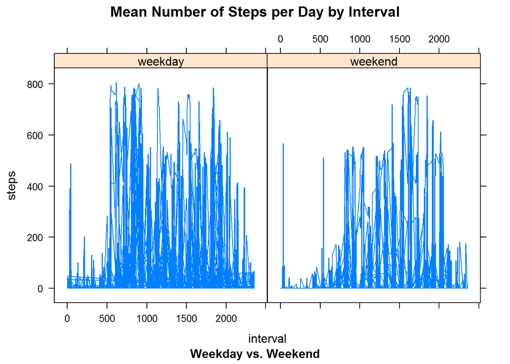

```r
# Convert "date" variable to date data type
activityNoNA$date <- as.Date(activityNoNA$date, format = "%Y-%m-%d")

# Determine weekday for date
activityNoNA$weekday <- weekdays(activityNoNA$date)

# Create indicator variable for whether 'weekday' variable was a day of the week or a day of the weekend
for (i in 1:nrow(activityNoNA))
{
  if ((activityNoNA$weekday[i] == "Saturday") || (activityNoNA$weekday[i] == "Sunday"))
      {
        activityNoNA$weekday.indicator[i] <- "weekend"
  }
  else
  {
    activityNoNA$weekday.indicator[i] <- "weekday"
  }
}

# Create time-series plot for the number of steps per day by interval, weekday vs. weekend
xyplot(steps ~ interval | weekday.indicator,
       data = activityNoNA,
       type = "l",
       main = "Mean Number of Steps per Day by Interval",
       sub = "Weekday vs. Weekend")
```

Ultimately, the data for weekday vs. weekend does, fundamentally look different. The data from the weekdays looks more voluminous, as expected, since it contains 5 days vs. the weekend data containing 2 days. Additionally, the weekend data seems to contain, on average, higher intervals, while the weekday data, for the most part, seems fairly evenly distributed after ~ the (495, 500) interval.

## **Conclusion**

- What is the mean total number of steps taken per day?
- What are the mean and median number of steps taken each day?
- What is the average daily activity pattern?
- Which 5-minute interval, on average across all the days in the dataset, contains the maximum number of steps?
- The data have missing values associated to particular days. After imputing an imputation strategy, do these imputed values differ from the estimates from the earlier determined values?
- What is the impact of imputing missing data on the estimates of the total daily number of steps?
- Are there differences in activity patterns between weekdays and weekends?